# COMPSCIX 415.2 Homework 2 SOLUTION

### 5.

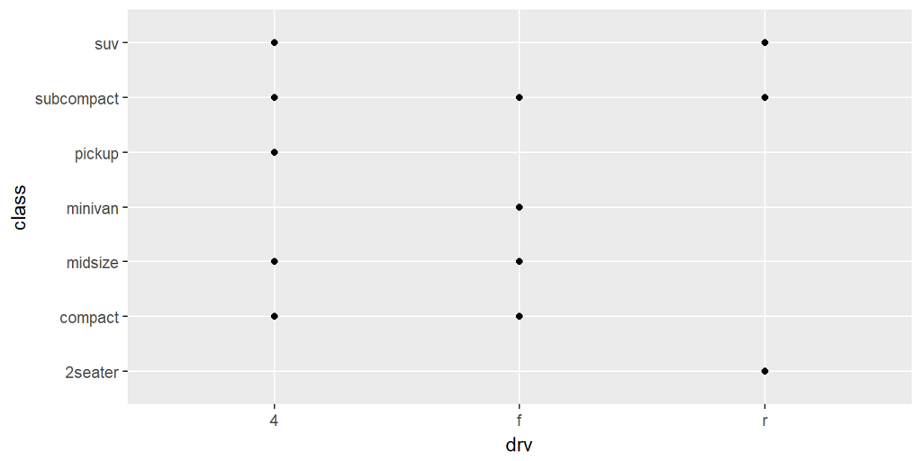

```r
ggplot(data = mpg) +
  geom_point(mapping = aes(x = drv, y = class))
```

Plotting class versus drive is not useful because these are both categorical variables, therefore the dots, which end up being plotted on top of each other, really don’t tell us anything about the relationship between drv and the class, or type of car.

## Section 3.3.1

### 1.

The points are not blue in the plot because aesthetics are mapped to variables in the data set when you include them in the `aes()` function. If you want to force a certain aesthic, you have to specify this outside of the `aes()` function.

### 2.

```r
mpg
```

| manufacturer | model | displ | year | cyl | trans | drv | cty | hwy | fl | class |
| --- | --- | --- | --- | --- | --- | --- | --- | --- | --- | --- |
| audi | a4 | 1.8 | 1999 | 4 | auto(l5) | f | 18 | 29 | p | compact |
| audi | a4 | 1.8 | 1999 | 4 | manual(m5) | f | 21 | 29 | p | compact |
| audi | a4 | 2.0 | 2008 | 4 | manual(m6) | f | 20 | 31 | p | compact |
| audi | a4 | 2.0 | 2008 | 4 | auto(av) | f | 21 | 30 | p | compact |
| audi | a4 | 2.8 | 1999 | 6 | auto(l5) | f | 16 | 26 | p | compact |
| audi | a4 | 2.8 | 1999 | 6 | manual(m5) | f | 18 | 26 | p | compact |
| audi | a4 | 3.1 | 2008 | 6 | auto(av) | f | 18 | 27 | p | compact |
| audi | a4 quattro | 1.8 | 1999 | 4 | manual(m5) | 4 | 18 | 26 | p | compact |
| audi | a4 quattro | 1.8 | 1999 | 4 | auto(l5) | 4 | 16 | 25 | p | compact |
| audi | a4 quattro | 2.0 | 2008 | 4 | manual(m6) | 4 | 20 | 28 | p | compact |

[output cut: 224 more lines]

By looking at the help file we can read the descriptions of each variable, but we can also see, at the top of each column when we print out the data set above, what type each column is.

Categorical variables are: manufacturer; model; cyl; trans; drv; fl; and class. Continuous variables are: displ; year; city; and hwy. Note that we could also interpret some variables that `R` has formatted as integers as ordinal variables, such as `year`.

### 3.

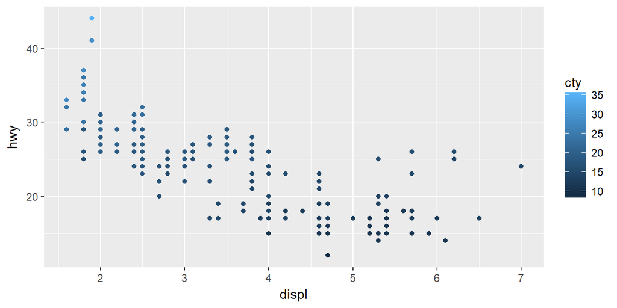

```r
ggplot(data = mpg) +
  geom_point(mapping = aes(x = displ, y = hwy, color = cty))
```

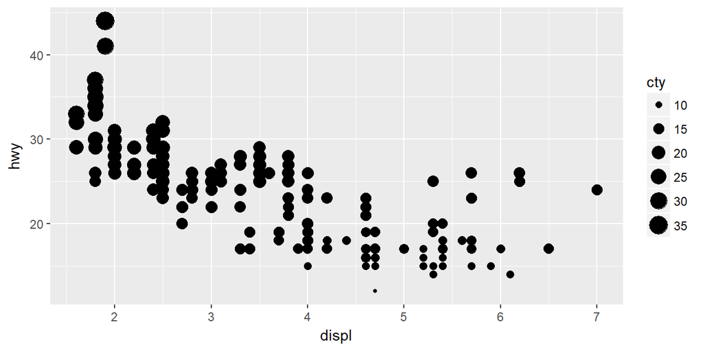

```r
ggplot(data = mpg) +
  geom_point(mapping = aes(x = displ, y = hwy, size = cty))
```

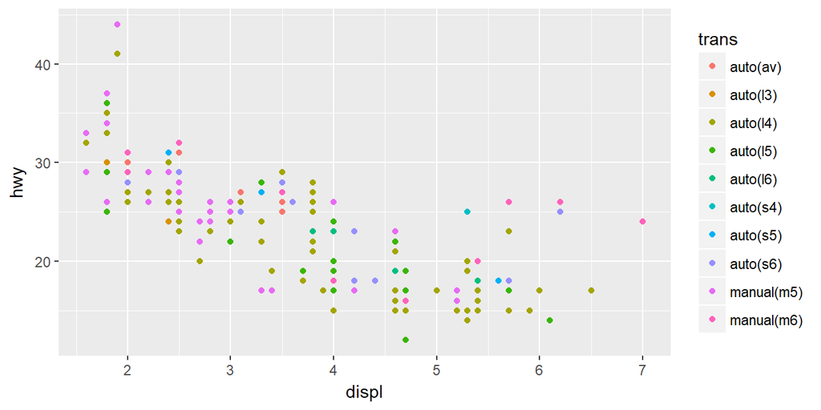

```r
# the below code throws an error
# ggplot(data = mpg) +
#   geom_point(mapping = aes(x = displ, y = hwy, shape = cty))

ggplot(data = mpg) +
  geom_point(mapping = aes(x = displ, y = hwy, color = trans))
```

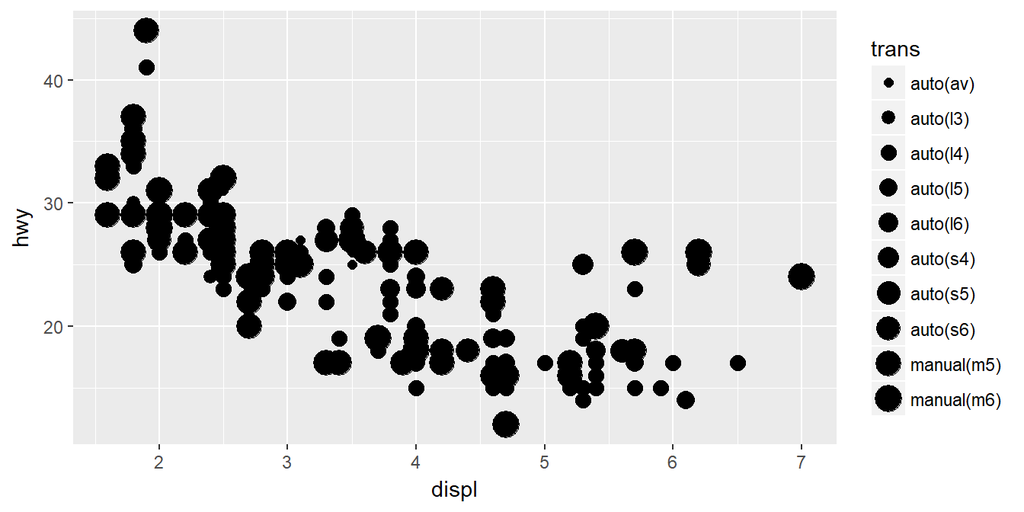

```r
ggplot(data = mpg) +
  geom_point(mapping = aes(x = displ, y = hwy, size = trans))
```

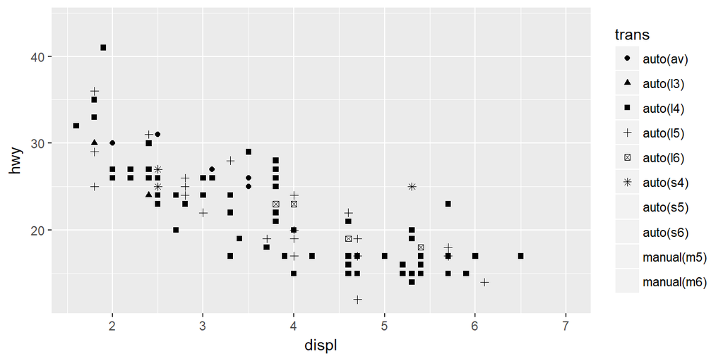

```r
ggplot(data = mpg) +
  geom_point(mapping = aes(x = displ, y = hwy, shape = trans))
```

For color, categorical variables are given discrete colors corresponding to categories, and the color palette does not have an order. Continuous variables have a gradient-style sequential color palette.

For size, categorical variables are given discrete sizes corresponding to categories, and it looks like the sizes correlate with the categories in alphabetical order. Continuous variables are binned in an automatic way and given sizes that correspond to the direction of the variable, e.g. getting bigger as the variable gets bigger.

For shape, a limited number of categories are given their own shapes. You cannot use the shape aesthetic with continuous variables.

### 4.

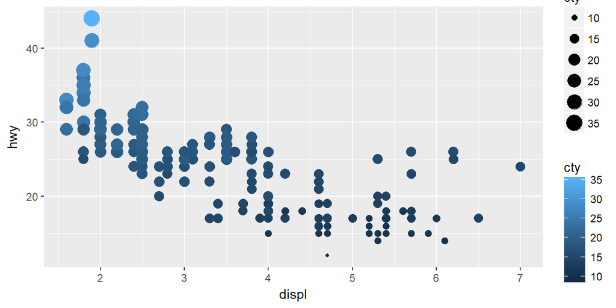

```r
ggplot(data = mpg) +
  geom_point(mapping = aes(x = displ, y = hwy, color = cty, size = cty))
```

When you map multiple aesthetics to the same variable, all aesthetics are plotted simultaneously and a legend is given for each one.

### 5.

From the help file for `geom_point()` there is an example at the bottom that describes that the stroke aesthetic can control the width of the border around the plotting points.

From the cheatsheet it looks like the stroke aesthetic only works for `geom_point()` and `geom_count()`.

### 6.

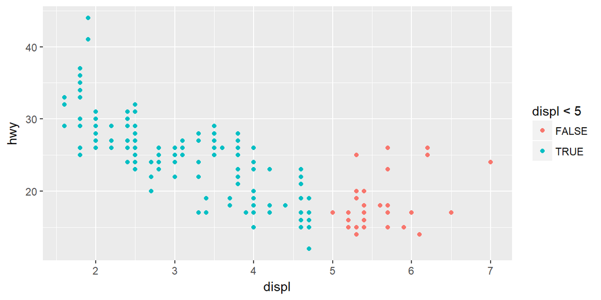

```r
ggplot(data = mpg) +
  geom_point(mapping = aes(x = displ, y = hwy, color = displ < 5))
```

Doing this seems to plot the results of the expression. So, for each observation, if displ < 5, then the point is given the category of TRUE, otherwise it is given the category of FALSE, and then the TRUE and FALSE categories are mapped to colors.

# Section 3.5.1: #4 and #5 only

### 4.

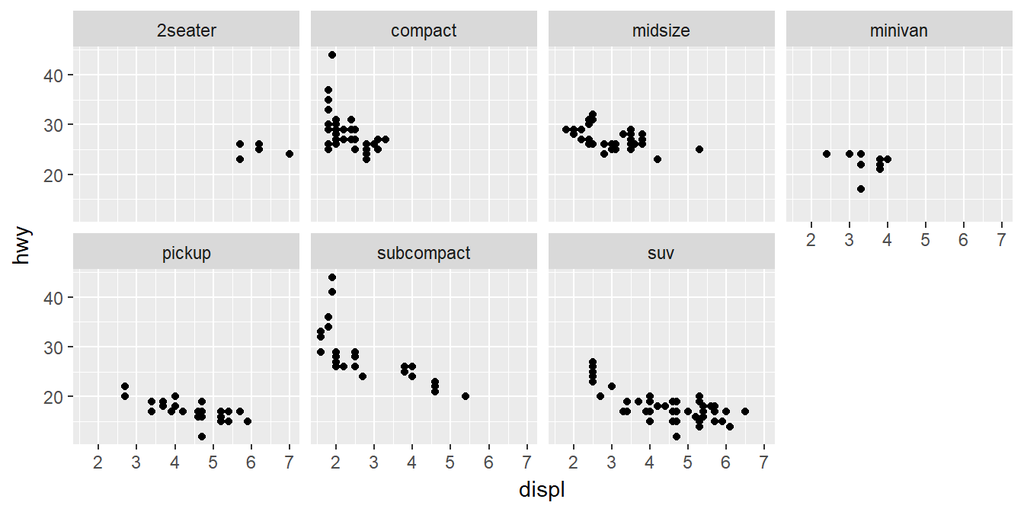

```r
ggplot(data = mpg) +
  geom_point(mapping = aes(x = displ, y = hwy)) +
  facet_wrap(~ class, nrow = 2)
```

The faceting can help reveal patterns which exist when broken down by categories. These patterns would otherwise be masked by the overlapping of points. For example, 2-seaters and compact cars are clumped together in a certain region of space corresponding to their engine size and gas mileage. This can sometimes be more useful than colors if there is a lot more data with overlapping points. On the other hand, we will not be able to observe any global relationships that may exist, but this is easily remedied by looking at a simple scatterplot.

### 5.

The `nrow` and `ncol` arguments describe how many rows and columns, respectively, the panels will be placed in. The `as.table` and `dir` arguments can also help you control the layout. `facet_grid` doesn’t use these arguments because you have to define your row and column facetting variables explicitly.

# Section 3.6.1: #1-5. Extra Credit: Do #6

### 1.

Line charts can be plotted with `geom_line()`, histograms with `geom_histogram`, boxplots with `geom_boxplot()`, and area charts with `geom_area`.

### 2.

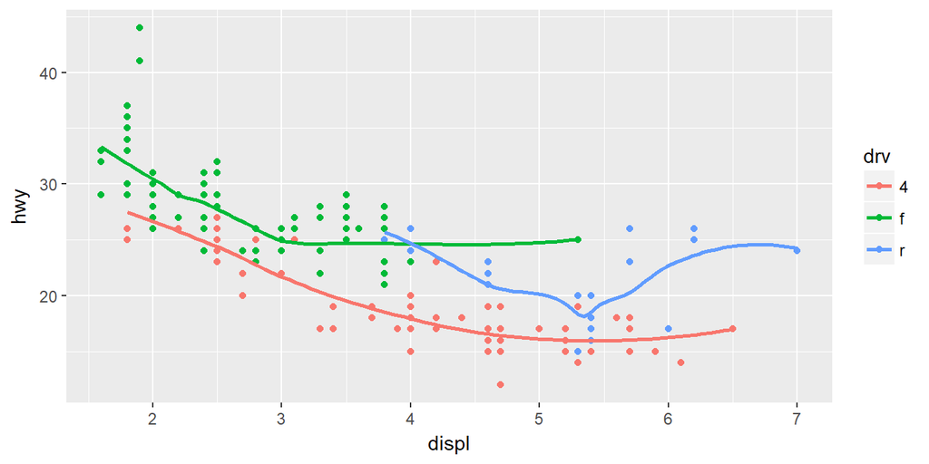

```r
ggplot(data = mpg, mapping = aes(x = displ, y = hwy, color = drv)) +
  geom_point() +
  geom_smooth(se = FALSE)
```

### 3.

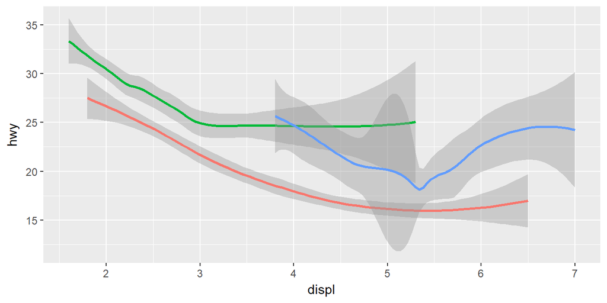

```r
ggplot(data = mpg) +
  geom_smooth(
    mapping = aes(x = displ, y = hwy, color = drv),
    show.legend = FALSE
  )
```

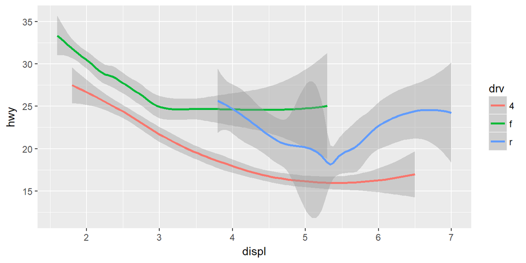

```r
ggplot(data = mpg) +
  geom_smooth(
    mapping = aes(x = displ, y = hwy, color = drv)
  )
```

`show.legend = FALSE` removes the legend for the `geom_smooth()`. It was used in the earlier example in this chapter to make comparing the three plots easier.

### 4.

The se argument to `geom_smooth()` creates and displays confidence intervals around the smoothed line.

### 5.

These two graphs should not look any different. In the first set of code the two geoms will use the same mapping that is defined in the `ggplot()` function. It’s a useful way to write less code.

### 6. (Extra Credit)

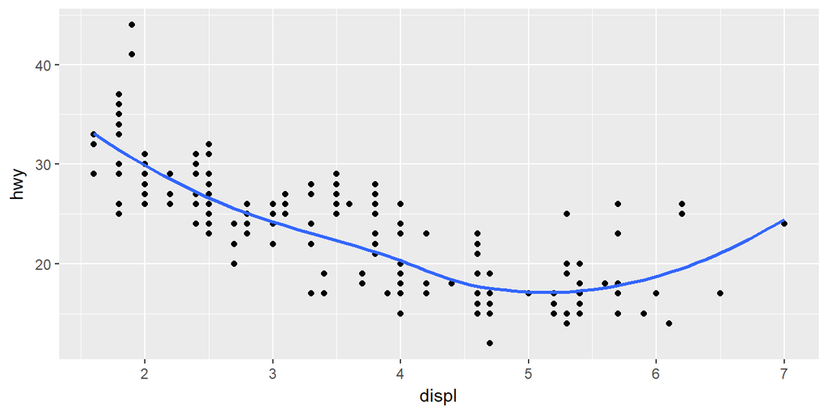

```r
ggplot(data = mpg, mapping = aes(x = displ, y = hwy)) +
  geom_point() +
  geom_smooth(se = FALSE)
```

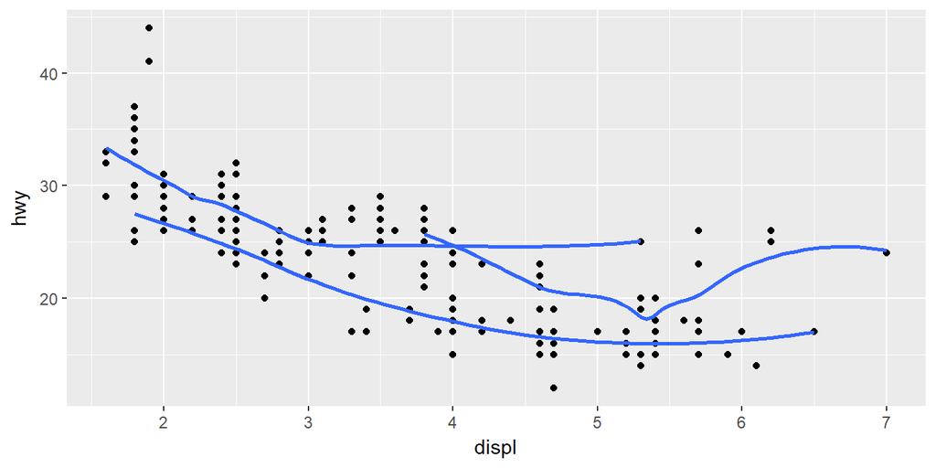

```r
ggplot(data = mpg, mapping = aes(x = displ, y = hwy, group = drv)) +
  geom_point() +
  geom_smooth(se = FALSE)
```

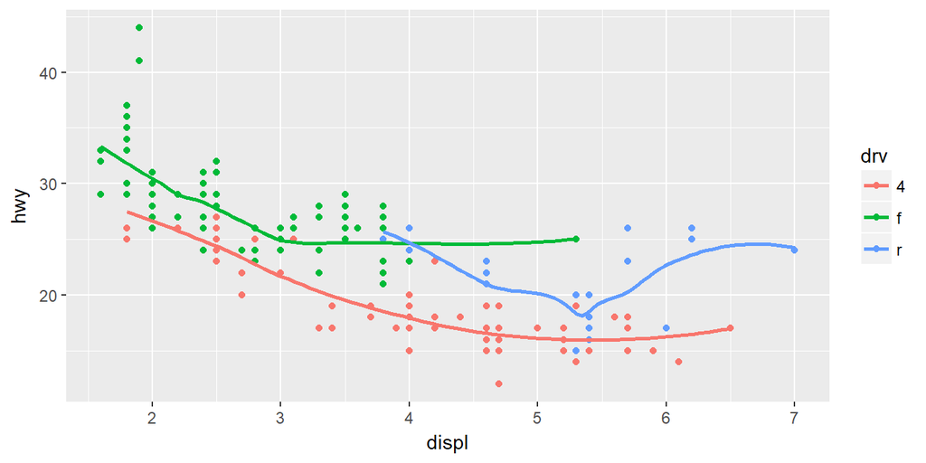

```r
ggplot(data = mpg, mapping = aes(x = displ, y = hwy, color = drv)) +
  geom_point() +
  geom_smooth(se = FALSE)
```

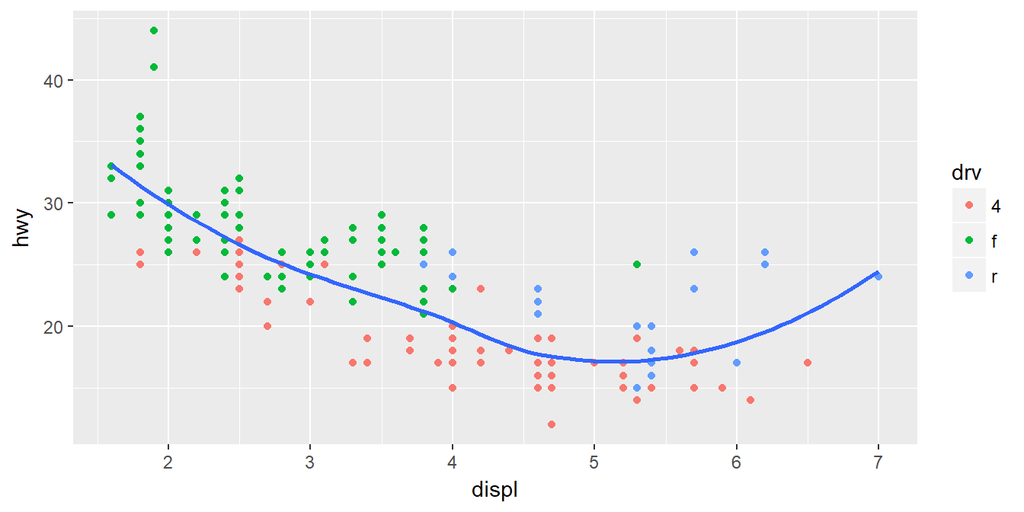

```r
ggplot(data = mpg, mapping = aes(x = displ, y = hwy)) +
  geom_point(aes(color = drv)) +
  geom_smooth(se = FALSE)
```

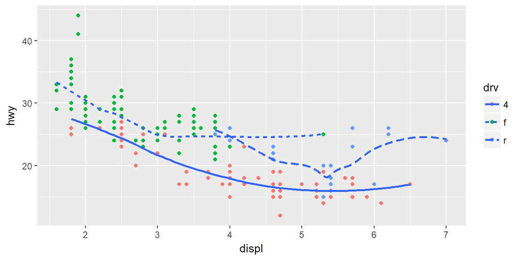

```r
ggplot(data = mpg, mapping = aes(x = displ, y = hwy)) +
  geom_point(aes(color = drv)) +
  geom_smooth(aes(linetype = drv), se = FALSE)
```

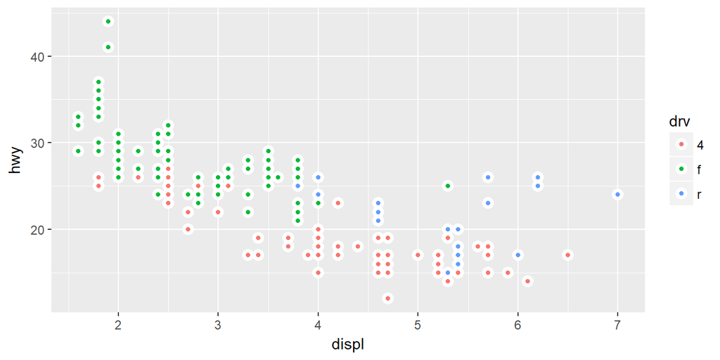

```r
ggplot(data = mpg, mapping = aes(x = displ, y = hwy, fill = drv)) +
  geom_point(shape = 21, stroke = 2, color = 'white')
```

# Section 3.7.1: #2 only

### 2.

`geom_col()` will also plot a bar chart, but it uses the data itself in order to define the heights of the bars, it doesn’t do any statistical transformations of the data to construct the bars of the plot.

### Answer these questions:

1. Look at the data graphics at the following link: [What is a Data Scientist](https://static.guim.co.uk/sys-images/Guardian/Pix/pictures/2012/3/2/1330695817953/EMC2-graphic-on-data-scie-008.jpg). Please briefly critique the designer’s choices. What works? What doesn’t work? What would you have done differently?

This is somewhat subjective. Some people will like some of the graphics and the color theme, whereas others will find fault in them. There is no *right* answer here. I’m mostly unimpressed by the graphics shown. Let’s take the first chart as an example. It isn’t intuitive to me that the categories here are actually ordinal, and that they go counter-clockwise around the circle. Also, what do the different colors represent for each section of the circle? Why not just use a bar chart, with the categories ordered from left to right (or top to bottom)?

Comparing the different fields of study between Data Scientists and Business Intelligence professionals with a bunch of overlapping circles is a strange choice to me. Again, I think the designers here were going for something “cute” rather than easily interpretable. It took me a minute or two to figure out what they were trying to do here.